# R Notebook

```r
library(tidyverse)
library(janitor)
library(infer)
library(ggplot2)
```

```r
msleep <-(data.frame(msleep))
```

##Q1 Jabberwockies (fantasy scary animal created by Lewis Carol ) sleeps for around 7 hours a night, on average. ##Perform an appropriate statistical test to determine whether the mean sleep_total in the sampled population of animal types differs from the typical value for jabberwockies. ##Mean sample for all animals v jabberwocky 7 hours

```r
mean_sleep <- msleep%>%
  select(sleep_total)%>%
   summarise(
    mean = mean(sleep_total),
    sd = sd(sleep_total))
```

##mean 10.4 and the standard deviation 4.4. ##mean for all animals is 10.4 v jabberwocky at 7hours. ##Sample does differ - visualalise now

```r
mean_sleep <- msleep%>%
  select(sleep_total)%>%
   summarise(
    mean = mean(sleep_total))
```

```r
msleep %>%
  ggplot(aes(x = sleep_total))+
  theme_classic()+
  geom_histogram( Col = "red")
```

```r
observed_stat_mean_avg_sleep <- msleep%>%
  select(sleep_total)%>%
   summarise(
    mean = mean(sleep_total))
```

```r
sleep_null_distribution <- msleep %>%
  specify(response = sleep_total)%>%
  hypothesise(null = "point", mu = 10.4)%>%
  generate(reps = 2000, type = "bootstrap")%>%
  calculate(stat = "mean")
```

```r
sleep_null_distribution %>%
  visualise(bins = 30)
```

```r
carni_sleep%>%
 summarise(
    mean = mean(sleep_total),
    sd = sd(sleep_total))
```

| mean | sd |
| --- | --- |
| 10.37895 | 4.669116 |

### Not sure why this is not working???

## Q2 Perform an appropriate statistical test to determine whether omnivores sleep for significantly longer than herbivores, on average.

```r
msleep%>%
  count(vore)
```

```r
msleep%>%
  select(vore, sleep_total)%>%
  filter(vore == c("carni", "omni"))
```

```r
carni_sleep <- msleep%>%
  select(vore, sleep_total)%>%
  filter(vore == c("carni"))
```

##Now create the mean

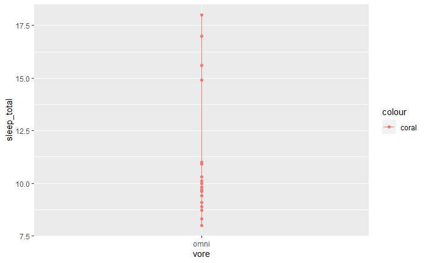

```r
ggplot(omni_sleep) +
  aes(x = vore, y = sleep_total, colour = "coral") +
  geom_line()+
  geom_point()
```

```r
  labs (x = "Diet", Y= "Total Hours Asleep in 24Hrs")+
    theme_classic()
```

##carni animals sleep on average 10.3 hours with an sd of 4.66

```r
msleep%>%
  select(vore, sleep_total)%>%
  filter(vore == c("carni", "omni"))
```

```r
ggplot(msleep) +
  aes(vore, sleep_total, colour = "red") +
  geom_point()+
  labs(x = "Diet")+
  labs (y = "Total hours sleep in 24hrs",)+
  coord_flip()
```

```r
omni_sleep <- msleep%>%
  select(vore, sleep_total)%>%
  filter(vore == c("omni"))
```

##GGplot Revision

```r
ggplot(omni_sleep) +
  aes(x = vore, y = sleep_total, colour = "coral") +
  geom_line()+
  geom_point()
  labs (x = "Diet", Y= "Total Hours Asleep in 24Hrs")+
    theme_classic()
```

##Now create the mean..

```r
omni_sleep%>%
 summarise(
    mean = mean(sleep_total),
    sd = sd(sleep_total))
```

omni animals sleep on average 10.9 hours with an sd of 2.9

Q4 Perform an appropriate statistical test to determine whether the proportion of domesticated animal types in the population of animal types is greater than 5%.

```r
msleep%>%
  count(conservation)
```

```r
msleep%>%
  filter(conservation == c("domesticated"))
```

Q 1.2 You work for a independent coffee shop. The boss tells you that she thinks that around 40% of people in the town (population 30,000) know of the coffee shop, but you are skeptical of the estimate. You conduct a random survey of 200 people in the town, asking if respondents are aware of your coffee shop. You want to use the sample to test the hypothesis that 40% or more of the town’s population have heard of the coffee shop.

Hypothesis Test

Estimated that 40% of the 30,000 population aware of the coffee shop (12,000 people)

Sample of 200 HO - 0.40 Ha = -0.40

##Q2.2 You selected five days at random last month and then randomly selected 200 of each sampled day’s users into group A and another 200 of that day’s users into group B. Group A continued to be shown the banner at the right hand side of the webpage (its usual position) while group B was shown the banner at the top of the page. You monitored each sampled user’s interactions with the website, in particular the ‘click through rate’ (CTR) on the banner, i.e. what proportion of sampled users clicked on the banner. You want to use the sampled data to test the hypothesis that website users overall are more likely to click on the banner if positioned at the top of the page

Hypotehsis testing

Coffee shop problem. Significance level: 0.05, calculated p-value: 0.07

Question 2.

Website company problem. Significance level: 0.01, p-value: 0.006

Question 3.